# A1_DatasetIris

Manuel Alejandro Preciado Morán A01639643

En este documento se encuentran las 3 practicas de iris

```python
# Import the packages that we will be using
import numpy as np
import pandas as pd
import matplotlib.pyplot as plt
import seaborn as sns
import csv

# Dataset url
path = "/home/alex/TC1002S/NotebooksStudents/A01639643/iris/iris.csv"
header = ["sepal_length", "sepal_width", "petal_length", "petal_width", "Class"]
# Load the dataset
dataset = pd.read_csv(path, names=header)

# Print the dataset
dataset
```

|  | sepal_length | sepal_width | petal_length | petal_width | Class |
| --- | --- | --- | --- | --- | --- |
| 0 | 5.1 | 3.5 | 1.4 | 0.2 | Iris-setosa |
| 1 | 4.9 | 3.0 | 1.4 | 0.2 | Iris-setosa |
| 2 | 4.7 | 3.2 | 1.3 | 0.2 | Iris-setosa |
| 3 | 4.6 | 3.1 | 1.5 | 0.2 | Iris-setosa |
| 4 | 5.0 | 3.6 | 1.4 | 0.2 | Iris-setosa |
| ... | ... | ... | ... | ... | ... |
| 145 | 6.7 | 3.0 | 5.2 | 2.3 | Iris-virginica |
| 146 | 6.3 | 2.5 | 5.0 | 1.9 | Iris-virginica |
| 147 | 6.5 | 3.0 | 5.2 | 2.0 | Iris-virginica |
| 148 | 6.2 | 3.4 | 5.4 | 2.3 | Iris-virginica |
| 149 | 5.9 | 3.0 | 5.1 | 1.8 | Iris-virginica |

150 rows × 5 columns

```python
#Print the number of rows(observations)
Nrows = dataset.shape[0]
Nrows
```

```
150
```

```python
#Print the number of columns
Ncol = dataset.shape[1]
Ncol
```

```
5
```

```python
# count1 = 0
# count2 = 0
# count3 = 0
# for i in range(Nrows):
#     if sC[i] == "Iris-setosa":
#         count1 += 1
#     elif sC[i] == "Iris-virginica":
#         count2 += 1
#     elif sC[i] == "Iris-versicolor":
#         count3 += 1
# count1
# count2
# count3
sC = dataset["Class"]
counts = pd.Series(sC).value_counts()
print("Iris-setosa: ", counts.get("Iris-setosa"))
print("Iris-virginica: ", counts.get("Iris-virginica"))
print("Iris-versicolor: ", counts.get("Iris-versicolor"))
```

```
Iris-setosa:  50
Iris-virginica:  50
Iris-versicolor:  50
```

Load the iris.csv file in your computer and understand the dataset

What is the type of data for each variable? float object

What are the units of each variable? cm

# PART 2

## Exploring the content of the data set

Use the shape method to determine the numbers of rows and columns in a data frame. This can be used to confirm that we have actually obtained the data the we are expecting.

```python
print(dataset.shape)
print("Number of rows", dataset.shape[0])
print("Number of columns/variables", dataset.shape[1])
```

```
(150, 5)
Number of rows 150
Number of columns/variables 5
```

If we want to show the entire data frame we would simply write the following:

```python
dataset
```

|  | sepal_length | sepal_width | petal_length | petal_width | Class |
| --- | --- | --- | --- | --- | --- |
| 0 | 5.1 | 3.5 | 1.4 | 0.2 | Iris-setosa |
| 1 | 4.9 | 3.0 | 1.4 | 0.2 | Iris-setosa |
| 2 | 4.7 | 3.2 | 1.3 | 0.2 | Iris-setosa |
| 3 | 4.6 | 3.1 | 1.5 | 0.2 | Iris-setosa |
| 4 | 5.0 | 3.6 | 1.4 | 0.2 | Iris-setosa |
| ... | ... | ... | ... | ... | ... |
| 145 | 6.7 | 3.0 | 5.2 | 2.3 | Iris-virginica |
| 146 | 6.3 | 2.5 | 5.0 | 1.9 | Iris-virginica |
| 147 | 6.5 | 3.0 | 5.2 | 2.0 | Iris-virginica |
| 148 | 6.2 | 3.4 | 5.4 | 2.3 | Iris-virginica |
| 149 | 5.9 | 3.0 | 5.1 | 1.8 | Iris-virginica |

150 rows × 5 columns

As you can see, we have a 2-Dimensional object where each row is an independent observation and each coloum is a variable.

Now, use the the head() function to show the first 5 rows of our data frame

```python
dataset.head()
```

|  | sepal_length | sepal_width | petal_length | petal_width | Class |
| --- | --- | --- | --- | --- | --- |
| 0 | 5.1 | 3.5 | 1.4 | 0.2 | Iris-setosa |
| 1 | 4.9 | 3.0 | 1.4 | 0.2 | Iris-setosa |
| 2 | 4.7 | 3.2 | 1.3 | 0.2 | Iris-setosa |
| 3 | 4.6 | 3.1 | 1.5 | 0.2 | Iris-setosa |
| 4 | 5.0 | 3.6 | 1.4 | 0.2 | Iris-setosa |

Also, you can use the the tail() function to show the last 5 rows of our data frame

```python
dataset.tail()
```

|  | sepal_length | sepal_width | petal_length | petal_width | Class |
| --- | --- | --- | --- | --- | --- |
| 145 | 6.7 | 3.0 | 5.2 | 2.3 | Iris-virginica |
| 146 | 6.3 | 2.5 | 5.0 | 1.9 | Iris-virginica |
| 147 | 6.5 | 3.0 | 5.2 | 2.0 | Iris-virginica |
| 148 | 6.2 | 3.4 | 5.4 | 2.3 | Iris-virginica |
| 149 | 5.9 | 3.0 | 5.1 | 1.8 | Iris-virginica |

The columns in a Pandas data frame have names, to see the names, use the columns method:

To gather more information regarding the data, we can view the column names with the following function

```python
dataset.columns
```

```
Index(['sepal_length', 'sepal_width', 'petal_length', 'petal_width', 'Class'], dtype='object')
```

Be aware that every variable in a Pandas data frame has a data type. There are many different data types, but most commonly you will encounter floating point values (real numbers), integers, strings (text), and date/time values. When Pandas reads a text/csv file, it guesses the data types based on what it sees in the first few rows of the data file. Usually it selects an appropriate type, but occasionally it does not. To confirm that the data types are consistent with what the variables represent, inspect the dtypes attribute of the data frame.

```python
dataset.dtypes
```

```
sepal_length    float64
sepal_width     float64
petal_length    float64
petal_width     float64
Class            object
dtype: object
```

Summary statistics, which include things like the mean, min, and max of the data, can be useful to get a feel for how large some of the variables are and what variables may be the most important.

```python
# Summary statistics for the quantitative variables
print("MEAN \n",dataset[["sepal_length", "sepal_width", "petal_length", "petal_width"]].mean())
print("MIN \n", dataset[["sepal_length", "sepal_width", "petal_length", "petal_width"]].min())
print("MAX \n",dataset[["sepal_length", "sepal_width", "petal_length", "petal_width"]].max())
```

```
MEAN
 sepal_length    5.843333
sepal_width     3.057333
petal_length    3.758000
petal_width     1.199333
dtype: float64
MIN
 sepal_length    4.3
sepal_width     2.0
petal_length    1.0
petal_width     0.1
dtype: float64
MAX
 sepal_length    7.9
sepal_width     4.4
petal_length    6.9
petal_width     2.5
dtype: float64
```

```python
dataset.describe()
```

|  | sepal_length | sepal_width | petal_length | petal_width |
| --- | --- | --- | --- | --- |
| count | 150.000000 | 150.000000 | 150.000000 | 150.000000 |
| mean | 5.843333 | 3.057333 | 3.758000 | 1.199333 |
| std | 0.828066 | 0.435866 | 1.765298 | 0.762238 |
| min | 4.300000 | 2.000000 | 1.000000 | 0.100000 |
| 25% | 5.100000 | 2.800000 | 1.600000 | 0.300000 |
| 50% | 5.800000 | 3.000000 | 4.350000 | 1.300000 |
| 75% | 6.400000 | 3.300000 | 5.100000 | 1.800000 |
| max | 7.900000 | 4.400000 | 6.900000 | 2.500000 |

```python
# Drop observations with NaN values
dataset.sepal_length.dropna().describe()
dataset.sepal_width.dropna().describe()
```

```
count    150.000000
mean       3.057333
std        0.435866
min        2.000000
25%        2.800000
50%        3.000000
75%        3.300000
max        4.400000
Name: sepal_width, dtype: float64
```

```python
print(dataset.mean())
print(dataset.corr())
print(dataset.count())
print(dataset.max())
print(dataset.min())
print(dataset.median())
print(dataset.std())
```

```
sepal_length    5.843333
sepal_width     3.057333
petal_length    3.758000
petal_width     1.199333
dtype: float64
              sepal_length  sepal_width  petal_length  petal_width
sepal_length      1.000000    -0.117570      0.871754     0.817941
sepal_width      -0.117570     1.000000     -0.428440    -0.366126
petal_length      0.871754    -0.428440      1.000000     0.962865
petal_width       0.817941    -0.366126      0.962865     1.000000
sepal_length    150
sepal_width     150
petal_length    150
petal_width     150
Class           150
dtype: int64
sepal_length               7.9
sepal_width                4.4
petal_length               6.9
petal_width                2.5
Class           Iris-virginica
dtype: object
sepal_length            4.3
sepal_width               2
petal_length              1
petal_width             0.1
Class           Iris-setosa
dtype: object
sepal_length    5.80
sepal_width     3.00
petal_length    4.35
petal_width     1.30
dtype: float64
sepal_length    0.828066
sepal_width     0.435866
petal_length    1.765298
petal_width     0.762238
dtype: float64
```

### How to write a data frame to a File

To save a file with your data simply use the to_csv attribute Examples df.to_csv('myDataFrame.csv') df.to_csv('myDataFrame.csv', sep='\t')

```python
dataset.to_csv('myDataFrame.csv')
```

### Rename columns

To change the name of a column use the rename attribute Example: df = df.rename(columns={"Age":"Edad}) df.head()

```python
dataset = dataset.rename(columns={"sepal length":"cambiado"})
dataset.head()
```

|  | sepal_length | sepal_width | petal_length | petal_width | Class |
| --- | --- | --- | --- | --- | --- |
| 0 | 5.1 | 3.5 | 1.4 | 0.2 | Iris-setosa |
| 1 | 4.9 | 3.0 | 1.4 | 0.2 | Iris-setosa |
| 2 | 4.7 | 3.2 | 1.3 | 0.2 | Iris-setosa |
| 3 | 4.6 | 3.1 | 1.5 | 0.2 | Iris-setosa |
| 4 | 5.0 | 3.6 | 1.4 | 0.2 | Iris-setosa |

```python
#Back to original name
dataset = dataset.rename(columns={"cambiado":"sepal_length"})
dataset.head()
```

|  | sepal_length | sepal_width | petal_length | petal_width | Class |
| --- | --- | --- | --- | --- | --- |
| 0 | 5.1 | 3.5 | 1.4 | 0.2 | Iris-setosa |
| 1 | 4.9 | 3.0 | 1.4 | 0.2 | Iris-setosa |
| 2 | 4.7 | 3.2 | 1.3 | 0.2 | Iris-setosa |
| 3 | 4.6 | 3.1 | 1.5 | 0.2 | Iris-setosa |
| 4 | 5.0 | 3.6 | 1.4 | 0.2 | Iris-setosa |

### Selection of columns

As discussed above, a Pandas data frame is a rectangular data table, in which the rows represent observations or samples and the columns represent variables. One common manipulation of a data frame is to extract the data for one case or for one variable. There are several ways to do this, as shown below.

To extract all the values for one column (variable), use one of the following alternatives.

```python
a = dataset.sepal_length
b = dataset["sepal_length"]
c = dataset.loc[:, "sepal_length"]
d = dataset.iloc[:, 0]

print(d)

dataset[["sepal_length", "sepal_width"]]
```

```
0      5.1
1      4.9
2      4.7
3      4.6
4      5.0
      ...
145    6.7
146    6.3
147    6.5
148    6.2
149    5.9
Name: sepal_length, Length: 150, dtype: float64
```

|  | sepal_length | sepal_width |
| --- | --- | --- |
| 0 | 5.1 | 3.5 |
| 1 | 4.9 | 3.0 |
| 2 | 4.7 | 3.2 |
| 3 | 4.6 | 3.1 |
| 4 | 5.0 | 3.6 |
| ... | ... | ... |
| 145 | 6.7 | 3.0 |
| 146 | 6.3 | 2.5 |
| 147 | 6.5 | 3.0 |
| 148 | 6.2 | 3.4 |
| 149 | 5.9 | 3.0 |

150 rows × 2 columns

```python
print(c)
```

```
0      5.1
1      4.9
2      4.7
3      4.6
4      5.0
      ...
145    6.7
146    6.3
147    6.5
148    6.2
149    5.9
Name: sepal_length, Length: 150, dtype: float64
```

### Slicing a data set

As discussed above, a Pandas data frame is a rectangular data table, in which the rows represent cases and the columns represent variables. One common manipulation of a data frame is to extract the data for one observation or for one variable. There are several ways to do this, as shown below.

Lets say we would like to splice our data frame and select only specific portions of our data. There are three different ways of doing so.

```
.loc()
.iloc()
.ix()
```

We will cover the .loc() and .iloc() splicing functions.

The attibute .loc() uses labels/column names, in specific, it takes two single/list/range operator separated by ',', the first one indicates the rows and the second one indicates columns.

```python
# Return all observations of CWDistance
dataset.loc[0:4,"sepal_length"]

# Return a subset of observations of CWDistance
dataset.loc[:9, "sepal_length"]

# Select all rows for multiple columns, ["Gender", "GenderGroup"]
dataset.loc[:,["sepal_length", "sepal_width"]]

# Select multiple columns, ["Gender", "GenderGroup"]me
keep = ['sepal_length', 'sepal_width']
df_sepal = dataset[keep]
df_sepal

# Select few rows for multiple columns, ["CWDistance", "Height", "Wingspan"]
dataset.loc[4:9, ["sepal_length", "sepal_width", "petal_length"]]

# Select range of rows for all columns
dataset.loc[10:15,:]
```

|  | sepal_length | sepal_width | petal_length | petal_width | Class |
| --- | --- | --- | --- | --- | --- |
| 10 | 5.4 | 3.7 | 1.5 | 0.2 | Iris-setosa |
| 11 | 4.8 | 3.4 | 1.6 | 0.2 | Iris-setosa |
| 12 | 4.8 | 3.0 | 1.4 | 0.1 | Iris-setosa |
| 13 | 4.3 | 3.0 | 1.1 | 0.1 | Iris-setosa |
| 14 | 5.8 | 4.0 | 1.2 | 0.2 | Iris-setosa |
| 15 | 5.7 | 4.4 | 1.5 | 0.4 | Iris-setosa |

The attribute iloc() is an integer based slicing

```python
# Only integer location for all the rows and only 0:4 columns
dataset.iloc[:, :4]

#All the colums and 0:3 rows
dataset.iloc[:4, :]

#All rows, columns 3:7
dataset.iloc[:, 3:7]

# Rows 4:8, columns 2:4
dataset.iloc[4:8, 2:4]

# This is incorrect:
# dataset.iloc[1:5, ["Gender", "GenderGroup"]]
```

|  | petal_length | petal_width |
| --- | --- | --- |
| 4 | 1.4 | 0.2 |
| 5 | 1.7 | 0.4 |
| 6 | 1.4 | 0.3 |
| 7 | 1.5 | 0.2 |

### Get unique existing values

List unique values in the one of the columns

df.Gender.unique()

```python
#List unique values in the df['petal_length'] column
dataset.petal_length.unique()
```

```
array([1.4, 1.3, 1.5, 1.7, 1.6, 1.1, 1.2, 1. , 1.9, 4.7, 4.5, 4.9, 4. ,
       4.6, 3.3, 3.9, 3.5, 4.2, 3.6, 4.4, 4.1, 4.8, 4.3, 5. , 3.8, 3.7,
       5.1, 3. , 6. , 5.9, 5.6, 5.8, 6.6, 6.3, 6.1, 5.3, 5.5, 6.7, 6.9,
       5.7, 6.4, 5.4, 5.2])
```

```python
#Lets explore df["petal_width"] as well
dataset.petal_width.unique()
```

```
array([0.2, 0.4, 0.3, 0.1, 0.5, 0.6, 1.4, 1.5, 1.3, 1.6, 1. , 1.1, 1.8,
       1.2, 1.7, 2.5, 1.9, 2.1, 2.2, 2. , 2.4, 2.3])
```

### Filter, Sort and Groupby

With Filter you can use different conditions to filter columns. For example, df[df[year] > 1984] would give you only the column year is greater than 1984. You can use & (and) or | (or) to add different conditions to your filtering. This is also called boolean filtering. df[df["Height"] >= 70]

```python
dataset[dataset["petal_length"] >=6.5]
```

|  | sepal_length | sepal_width | petal_length | petal_width | Class |
| --- | --- | --- | --- | --- | --- |
| 105 | 7.6 | 3.0 | 6.6 | 2.1 | Iris-virginica |
| 117 | 7.7 | 3.8 | 6.7 | 2.2 | Iris-virginica |
| 118 | 7.7 | 2.6 | 6.9 | 2.3 | Iris-virginica |
| 122 | 7.7 | 2.8 | 6.7 | 2.0 | Iris-virginica |

With Sort is possible to sort values in a certain column in an ascending order using df.sort_values("ColumnName") or in descending order using df.sort_values(ColumnName, ascending=False).

Furthermore, it’s possible to sort values by Column1Name in ascending order then Column2Name in descending order by using df.sort_values([Column1Name,Column2Name],ascending=[True,False])

df.sort_values("Height")

```python
dataset.sort_values("petal_length", ascending=False)
```

|  | sepal_length | sepal_width | petal_length | petal_width | Class |
| --- | --- | --- | --- | --- | --- |
| 118 | 7.7 | 2.6 | 6.9 | 2.3 | Iris-virginica |
| 122 | 7.7 | 2.8 | 6.7 | 2.0 | Iris-virginica |
| 117 | 7.7 | 3.8 | 6.7 | 2.2 | Iris-virginica |
| 105 | 7.6 | 3.0 | 6.6 | 2.1 | Iris-virginica |
| 131 | 7.9 | 3.8 | 6.4 | 2.0 | Iris-virginica |
| ... | ... | ... | ... | ... | ... |
| 16 | 5.4 | 3.9 | 1.3 | 0.4 | Iris-setosa |
| 35 | 5.0 | 3.2 | 1.2 | 0.2 | Iris-setosa |
| 14 | 5.8 | 4.0 | 1.2 | 0.2 | Iris-setosa |
| 13 | 4.3 | 3.0 | 1.1 | 0.1 | Iris-setosa |
| 22 | 4.6 | 3.6 | 1.0 | 0.2 | Iris-setosa |

150 rows × 5 columns

The attribute Groupby involves splitting the data into groups based on some criteria, applying a function to each group independently and combining the results into a data structure. df.groupby(col) returns a groupby object for values from one column while df.groupby([col1,col2]) returns a groupby object for values from multiple columns.

df.groupby(['Gender'])

```python
dataset.groupby(['sepal_length'])
```

```
<pandas.core.groupby.generic.DataFrameGroupBy object at 0x7f9b82012c50>
```

Size of each group

df.groupby(['Gender']).size()

df.groupby(['Gender','GenderGroup']).size()

```python
dataset.groupby(['sepal_length']).size()
dataset.groupby(['sepal_length', 'Class']).size()
```

```
sepal_length  Class
4.3           Iris-setosa        1
4.4           Iris-setosa        3
4.5           Iris-setosa        1
4.6           Iris-setosa        4
4.7           Iris-setosa        2
4.8           Iris-setosa        5
4.9           Iris-setosa        4
              Iris-versicolor    1
              Iris-virginica     1
5.0           Iris-setosa        8
              Iris-versicolor    2
5.1           Iris-setosa        8
              Iris-versicolor    1
5.2           Iris-setosa        3
              Iris-versicolor    1
5.3           Iris-setosa        1
5.4           Iris-setosa        5
              Iris-versicolor    1
5.5           Iris-setosa        2
              Iris-versicolor    5
5.6           Iris-versicolor    5
              Iris-virginica     1
5.7           Iris-setosa        2
              Iris-versicolor    5
              Iris-virginica     1
5.8           Iris-setosa        1
              Iris-versicolor    3
              Iris-virginica     3
5.9           Iris-versicolor    2
              Iris-virginica     1
6.0           Iris-versicolor    4
              Iris-virginica     2
6.1           Iris-versicolor    4
              Iris-virginica     2
6.2           Iris-versicolor    2
              Iris-virginica     2
6.3           Iris-versicolor    3
              Iris-virginica     6
6.4           Iris-versicolor    2
              Iris-virginica     5
6.5           Iris-versicolor    1
              Iris-virginica     4
6.6           Iris-versicolor    2
6.7           Iris-versicolor    3
              Iris-virginica     5
6.8           Iris-versicolor    1
              Iris-virginica     2
6.9           Iris-versicolor    1
              Iris-virginica     3
7.0           Iris-versicolor    1
7.1           Iris-virginica     1
7.2           Iris-virginica     3
7.3           Iris-virginica     1
7.4           Iris-virginica     1
7.6           Iris-virginica     1
7.7           Iris-virginica     4
7.9           Iris-virginica     1
dtype: int64
```

[output not shown]

### Data Cleaning: handle with missing data

Before getting started to work with your data, it's a good practice to observe it thoroughly to identify missing values and handle them accordingly.

When reading a dataset using Pandas, there is a set of values including 'NA', 'NULL', and 'NaN' that are taken by default to represent a missing value. The full list of default missing value codes is in the 'read_csv' documentation here. This document also explains how to change the way that 'read_csv' decides whether a variable's value is missing.

Pandas has functions called isnull and notnull that can be used to identify where the missing and non-missing values are located in a data frame.

Below we use these functions to count the number of missing and non-missing values in each variable of the datasetr.

```python
dataset.isnull()
```

|  | sepal_length | sepal_width | petal_length | petal_width | Class |
| --- | --- | --- | --- | --- | --- |
| 0 | False | False | False | False | False |
| 1 | False | False | False | False | False |
| 2 | False | False | False | False | False |
| 3 | False | False | False | False | False |
| 4 | False | False | False | False | False |
| ... | ... | ... | ... | ... | ... |
| 145 | False | False | False | False | False |
| 146 | False | False | False | False | False |
| 147 | False | False | False | False | False |
| 148 | False | False | False | False | False |
| 149 | False | False | False | False | False |

150 rows × 5 columns

```python
dataset.notnull()
```

|  | sepal_length | sepal_width | petal_length | petal_width | Class |
| --- | --- | --- | --- | --- | --- |
| 0 | True | True | True | True | True |
| 1 | True | True | True | True | True |
| 2 | True | True | True | True | True |
| 3 | True | True | True | True | True |
| 4 | True | True | True | True | True |
| ... | ... | ... | ... | ... | ... |
| 145 | True | True | True | True | True |
| 146 | True | True | True | True | True |
| 147 | True | True | True | True | True |
| 148 | True | True | True | True | True |
| 149 | True | True | True | True | True |

150 rows × 5 columns

```python
dataset.isnull().sum()
```

```
sepal_length    0
sepal_width     0
petal_length    0
petal_width     0
Class           0
dtype: int64
```

```python
dataset.notnull().sum()
```

```
sepal_length    150
sepal_width     150
petal_length    150
petal_width     150
Class           150
dtype: int64
```

Now we use these functions to count the number of missing and non-missing values in a single variable in the dataset

print( df.Height.notnull().sum() )

print( pd.isnull(df.Height).sum() )

```python
print( dataset.petal_length.notnull().sum() )

print( pd.isnull(dataset.petal_width).sum() )
```

```
150
0
```

```python
# Extract all non-missing values of one of the columns into a new variable
#x = df.Age.dropna().describe()
#x.describe()
```

### Add and eliminate columns

In some cases it is useful to create or eliminate new columns

```python
dataset.head()
```

|  | sepal_length | sepal_width | petal_length | petal_width | Class |
| --- | --- | --- | --- | --- | --- |
| 0 | 5.1 | 3.5 | 1.4 | 0.2 | Iris-setosa |
| 1 | 4.9 | 3.0 | 1.4 | 0.2 | Iris-setosa |
| 2 | 4.7 | 3.2 | 1.3 | 0.2 | Iris-setosa |
| 3 | 4.6 | 3.1 | 1.5 | 0.2 | Iris-setosa |
| 4 | 5.0 | 3.6 | 1.4 | 0.2 | Iris-setosa |

```python
# Add a new column with new data

# Create a column data
NewColumnData = dataset.sepal_length/dataset.sepal_length

# Insert that column in the data frame
dataset.insert(5, "ColumnInserted", NewColumnData, True)

dataset.head()
```

|  | sepal_length | sepal_width | petal_length | petal_width | Class | ColumnInserted |
| --- | --- | --- | --- | --- | --- | --- |
| 0 | 5.1 | 3.5 | 1.4 | 0.2 | Iris-setosa | 1.0 |
| 1 | 4.9 | 3.0 | 1.4 | 0.2 | Iris-setosa | 1.0 |
| 2 | 4.7 | 3.2 | 1.3 | 0.2 | Iris-setosa | 1.0 |
| 3 | 4.6 | 3.1 | 1.5 | 0.2 | Iris-setosa | 1.0 |
| 4 | 5.0 | 3.6 | 1.4 | 0.2 | Iris-setosa | 1.0 |

```python
# # Eliminate inserted column
# dataset.drop("ColumnInserted", axis=1, inplace = True)
dataset.drop(columns=['ColumnInserted'], inplace = True)
# # Remove three columns as index base
# dataset.drop(dataset.columns[[5]], axis = 1, inplace = True)

dataset.head()
```

|  | sepal_length | sepal_width | petal_length | petal_width | Class |
| --- | --- | --- | --- | --- | --- |
| 0 | 5.1 | 3.5 | 1.4 | 0.2 | Iris-setosa |
| 1 | 4.9 | 3.0 | 1.4 | 0.2 | Iris-setosa |
| 2 | 4.7 | 3.2 | 1.3 | 0.2 | Iris-setosa |
| 3 | 4.6 | 3.1 | 1.5 | 0.2 | Iris-setosa |
| 4 | 5.0 | 3.6 | 1.4 | 0.2 | Iris-setosa |

```python
# # Add new column derived from existing columns
#
# # The new column is a function of another column
dataset["sepal_length m"] = dataset["sepal_length"] * 100

dataset.head()
```

|  | sepal_length | sepal_width | petal_length | petal_width | Class | sepal_length m |
| --- | --- | --- | --- | --- | --- | --- |
| 0 | 5.1 | 3.5 | 1.4 | 0.2 | Iris-setosa | 510.0 |
| 1 | 4.9 | 3.0 | 1.4 | 0.2 | Iris-setosa | 490.0 |
| 2 | 4.7 | 3.2 | 1.3 | 0.2 | Iris-setosa | 470.0 |
| 3 | 4.6 | 3.1 | 1.5 | 0.2 | Iris-setosa | 460.0 |
| 4 | 5.0 | 3.6 | 1.4 | 0.2 | Iris-setosa | 500.0 |

```python
# # Eliminate inserted column
dataset.drop("sepal_length m", axis=1, inplace = True)

dataset.head()
```

|  | sepal_length | sepal_width | petal_length | petal_width | Class |
| --- | --- | --- | --- | --- | --- |
| 0 | 5.1 | 3.5 | 1.4 | 0.2 | Iris-setosa |
| 1 | 4.9 | 3.0 | 1.4 | 0.2 | Iris-setosa |
| 2 | 4.7 | 3.2 | 1.3 | 0.2 | Iris-setosa |
| 3 | 4.6 | 3.1 | 1.5 | 0.2 | Iris-setosa |
| 4 | 5.0 | 3.6 | 1.4 | 0.2 | Iris-setosa |

```python
dataset.tail()
```

|  | sepal_length | sepal_width | petal_length | petal_width | Class |
| --- | --- | --- | --- | --- | --- |
| 145 | 6.7 | 3.0 | 5.2 | 2.3 | Iris-virginica |
| 146 | 6.3 | 2.5 | 5.0 | 1.9 | Iris-virginica |
| 147 | 6.5 | 3.0 | 5.2 | 2.0 | Iris-virginica |
| 148 | 6.2 | 3.4 | 5.4 | 2.3 | Iris-virginica |
| 149 | 5.9 | 3.0 | 5.1 | 1.8 | Iris-virginica |

```python
# Add a new column with text labels reflecting the code's meaning

dataset["ClassNEW"] = dataset.Class.replace({"Iris-setosa": "Is", "Iris-virginica": "Iv"})

# Show the first 5 rows of the created data frame
dataset.head()
```

|  | sepal_length | sepal_width | petal_length | petal_width | Class | ClassNEW |
| --- | --- | --- | --- | --- | --- | --- |
| 0 | 5.1 | 3.5 | 1.4 | 0.2 | Iris-setosa | Is |
| 1 | 4.9 | 3.0 | 1.4 | 0.2 | Iris-setosa | Is |
| 2 | 4.7 | 3.2 | 1.3 | 0.2 | Iris-setosa | Is |
| 3 | 4.6 | 3.1 | 1.5 | 0.2 | Iris-setosa | Is |
| 4 | 5.0 | 3.6 | 1.4 | 0.2 | Iris-setosa | Is |

```python
## Eliminate inserted column
dataset.drop("ClassNEW", axis=1, inplace = True)
##df.drop(['GenderGroupNew'],vaxis='columns',vinplace=True)
dataset.head()
```

|  | sepal_length | sepal_width | petal_length | petal_width | Class |
| --- | --- | --- | --- | --- | --- |
| 0 | 5.1 | 3.5 | 1.4 | 0.2 | Iris-setosa |
| 1 | 4.9 | 3.0 | 1.4 | 0.2 | Iris-setosa |
| 2 | 4.7 | 3.2 | 1.3 | 0.2 | Iris-setosa |
| 3 | 4.6 | 3.1 | 1.5 | 0.2 | Iris-setosa |
| 4 | 5.0 | 3.6 | 1.4 | 0.2 | Iris-setosa |

```python
## Add a new column with strata based on these cut points
#
## Create a column data
NewColumnData = dataset.sepal_length * 100

## Insert that column in the data frame
dataset.insert(1, "ColumnStrata", NewColumnData, True)
#
dataset["ColumnStrata"] = pd.cut(dataset.ColumnStrata, [60., 63., 66., 69., 72., 75., 78.])
#
## Show the first 5 rows of the created data frame
dataset.head()
```

|  | sepal_length | ColumnStrata | sepal_width | petal_length | petal_width | Class |
| --- | --- | --- | --- | --- | --- | --- |
| 0 | 5.1 | NaN | 3.5 | 1.4 | 0.2 | Iris-setosa |
| 1 | 4.9 | NaN | 3.0 | 1.4 | 0.2 | Iris-setosa |
| 2 | 4.7 | NaN | 3.2 | 1.3 | 0.2 | Iris-setosa |
| 3 | 4.6 | NaN | 3.1 | 1.5 | 0.2 | Iris-setosa |
| 4 | 5.0 | NaN | 3.6 | 1.4 | 0.2 | Iris-setosa |

```python
## Eliminate inserted column
dataset.drop("ColumnStrata", axis=1, inplace = True)
#
dataset.head()
```

|  | sepal_length | sepal_width | petal_length | petal_width | Class |
| --- | --- | --- | --- | --- | --- |
| 0 | 5.1 | 3.5 | 1.4 | 0.2 | Iris-setosa |
| 1 | 4.9 | 3.0 | 1.4 | 0.2 | Iris-setosa |
| 2 | 4.7 | 3.2 | 1.3 | 0.2 | Iris-setosa |
| 3 | 4.6 | 3.1 | 1.5 | 0.2 | Iris-setosa |
| 4 | 5.0 | 3.6 | 1.4 | 0.2 | Iris-setosa |

```python
# Drop several "unused" columns
#vars = ["ID", "GenderGroup", "GlassesGroup", "CompleteGroup"]
#df.drop(vars, axis=1, inplace = True)
```

### Add and eliminate rows

In some cases it is requiered to add new observations (rows) to the data set

```python
#print tail
dataset.tail()
```

|  | sepal_length | sepal_width | petal_length | petal_width | Class |
| --- | --- | --- | --- | --- | --- |
| 145 | 6.7 | 3.0 | 5.2 | 2.3 | Iris-virginica |
| 146 | 6.3 | 2.5 | 5.0 | 1.9 | Iris-virginica |
| 147 | 6.5 | 3.0 | 5.2 | 2.0 | Iris-virginica |
| 148 | 6.2 | 3.4 | 5.4 | 2.3 | Iris-virginica |
| 149 | 5.9 | 3.0 | 5.1 | 1.8 | Iris-virginica |

```python
dataset.loc[len(dataset.index)] = [6.0, 3.2, 4.9, 1.4, "Iris-virginica"]

dataset.tail()
```

|  | sepal_length | sepal_width | petal_length | petal_width | Class |
| --- | --- | --- | --- | --- | --- |
| 146 | 6.3 | 2.5 | 5.0 | 1.9 | Iris-virginica |
| 147 | 6.5 | 3.0 | 5.2 | 2.0 | Iris-virginica |
| 148 | 6.2 | 3.4 | 5.4 | 2.3 | Iris-virginica |
| 149 | 5.9 | 3.0 | 5.1 | 1.8 | Iris-virginica |
| 150 | 6.0 | 3.2 | 4.9 | 1.4 | Iris-virginica |

### Cleaning your data: drop out unused columns and/or drop out rows with any missing values

```python
# Drop unused columns
#vars = ["ID", "GenderGroup", "GlassesGroup", "CompleteGroup"]
#df.drop(vars, axis=1, inplace = True)

#vars = ["Age", "Gender", "Glasses", "Height", "Wingspan", "CWDistance", "Complete", "Score"]
#df = df[vars]

# Drop rows with any missing values
dataset = dataset.dropna()

# Drop unused columns and drop rows with any missing values
vars = ["sepal_length", "sepal_width", "petal_length", "petal_width", "Class"]
dataset = dataset[vars].dropna()

dataset
```

|  | sepal_length | sepal_width | petal_length | petal_width | Class |
| --- | --- | --- | --- | --- | --- |
| 0 | 5.1 | 3.5 | 1.4 | 0.2 | Iris-setosa |
| 1 | 4.9 | 3.0 | 1.4 | 0.2 | Iris-setosa |
| 2 | 4.7 | 3.2 | 1.3 | 0.2 | Iris-setosa |
| 3 | 4.6 | 3.1 | 1.5 | 0.2 | Iris-setosa |
| 4 | 5.0 | 3.6 | 1.4 | 0.2 | Iris-setosa |
| ... | ... | ... | ... | ... | ... |
| 146 | 6.3 | 2.5 | 5.0 | 1.9 | Iris-virginica |
| 147 | 6.5 | 3.0 | 5.2 | 2.0 | Iris-virginica |
| 148 | 6.2 | 3.4 | 5.4 | 2.3 | Iris-virginica |
| 149 | 5.9 | 3.0 | 5.1 | 1.8 | Iris-virginica |
| 150 | 6.0 | 3.2 | 4.9 | 1.4 | Iris-virginica |

151 rows × 5 columns

## Activity: work with the iris dataset

Repeat this tutorial with the iris data set and respond to the following inquiries

```
Calculate the statistical summary for each quantitative variables. Explain the results
    Identify the name of each column
    Identify the type of each column
    Minimum, maximum, mean, average, median, standar deviation

Are there missing data? If so, create a new dataset containing only the rows with the non-missing data
NO

Create a new dataset containing only the petal width and length and the type of Flower

Create a new dataset containing only the setal width and length and the type of Flower

Create a new dataset containing the setal width and length and the type of Flower encoded as a categorical numerical column
```

```python
#Identifty the name of each column
dataset.columns
```

```
Index(['sepal_length', 'sepal_width', 'petal_length', 'petal_width', 'Class'], dtype='object')
```

```python
#Identifty the type of each column
dataset.dtypes
```

```
sepal_length    float64
sepal_width     float64
petal_length    float64
petal_width     float64
Class            object
dtype: object
```

```python
#Minimum, maximum, mean, average, median, standar deviation
dataset.describe()
```

|  | sepal_length | sepal_width | petal_length | petal_width |
| --- | --- | --- | --- | --- |
| count | 151.000000 | 151.000000 | 151.000000 | 151.000000 |
| mean | 5.844371 | 3.058278 | 3.765563 | 1.200662 |
| std | 0.825400 | 0.434566 | 1.761857 | 0.759868 |
| min | 4.300000 | 2.000000 | 1.000000 | 0.100000 |
| 25% | 5.100000 | 2.800000 | 1.600000 | 0.300000 |
| 50% | 5.800000 | 3.000000 | 4.400000 | 1.300000 |
| 75% | 6.400000 | 3.300000 | 5.100000 | 1.800000 |
| max | 7.900000 | 4.400000 | 6.900000 | 2.500000 |

```python
# Create a new dataset containing only the petal width and length and the type of Flower
ds1 = dataset.iloc[:,2:4]
ds1
```

|  | petal_length | petal_width |
| --- | --- | --- |
| 0 | 1.4 | 0.2 |
| 1 | 1.4 | 0.2 |
| 2 | 1.3 | 0.2 |
| 3 | 1.5 | 0.2 |
| 4 | 1.4 | 0.2 |
| ... | ... | ... |
| 146 | 5.0 | 1.9 |
| 147 | 5.2 | 2.0 |
| 148 | 5.4 | 2.3 |
| 149 | 5.1 | 1.8 |
| 150 | 4.9 | 1.4 |

151 rows × 2 columns

```python
# Create a new dataset containing only the setal width and length and the type of Flower
ds2 = dataset.iloc[:,0:2]
ds2
```

|  | sepal_length | sepal_width |
| --- | --- | --- |
| 0 | 5.1 | 3.5 |
| 1 | 4.9 | 3.0 |
| 2 | 4.7 | 3.2 |
| 3 | 4.6 | 3.1 |
| 4 | 5.0 | 3.6 |
| ... | ... | ... |
| 146 | 6.3 | 2.5 |
| 147 | 6.5 | 3.0 |
| 148 | 6.2 | 3.4 |
| 149 | 5.9 | 3.0 |
| 150 | 6.0 | 3.2 |

151 rows × 2 columns

```python
# Create a new dataset containing the setal width and length and the type of Flower encoded as a categorical numerical column
ds2 = dataset.loc[:,["sepal_length", "sepal_width", "Class"]]
ds2["Class"] = ds2.Class.replace({"Iris-setosa":1, "Iris-versicolor":2, "Iris-virginica":3})
ds2
```

|  | sepal_length | sepal_width | Class |
| --- | --- | --- | --- |
| 0 | 5.1 | 3.5 | 1 |
| 1 | 4.9 | 3.0 | 1 |
| 2 | 4.7 | 3.2 | 1 |
| 3 | 4.6 | 3.1 | 1 |
| 4 | 5.0 | 3.6 | 1 |
| ... | ... | ... | ... |
| 146 | 6.3 | 2.5 | 3 |
| 147 | 6.5 | 3.0 | 3 |
| 148 | 6.2 | 3.4 | 3 |
| 149 | 5.9 | 3.0 | 3 |
| 150 | 6.0 | 3.2 | 3 |

151 rows × 3 columns

# PART 3

### Importing data

```python
# Dataset url
path = "/home/alex/TC1002S/NotebooksStudents/A01639643/iris/iris.csv"
header = ["sepal_length", "sepal_width", "petal_length", "petal_width", "Class"]
# Load the dataset
ds = pd.read_csv(path, names=header)
```

### Exploring th content of the data set

Get a general 'feel' of the data

```python
ds
ds.dtypes
ds.describe()
```

|  | sepal_length | sepal_width | petal_length | petal_width |
| --- | --- | --- | --- | --- |
| count | 150.000000 | 150.000000 | 150.000000 | 150.000000 |
| mean | 5.843333 | 3.057333 | 3.758000 | 1.199333 |
| std | 0.828066 | 0.435866 | 1.765298 | 0.762238 |
| min | 4.300000 | 2.000000 | 1.000000 | 0.100000 |
| 25% | 5.100000 | 2.800000 | 1.600000 | 0.300000 |
| 50% | 5.800000 | 3.000000 | 4.350000 | 1.300000 |
| 75% | 6.400000 | 3.300000 | 5.100000 | 1.800000 |
| max | 7.900000 | 4.400000 | 6.900000 | 2.500000 |

### Frequency Tables

```python
#Number of times that each distinct value of a variable occurs in a data set
ds["Class"].value_counts()
```

```
Iris-virginica     50
Iris-versicolor    50
Iris-setosa        50
Name: Class, dtype: int64
```

```python
#Proportion of each distinct value of a variable occurs in a data set
fd = ds["Class"].value_counts()/ds["Class"].count()*100
fd
```

```
Iris-virginica     33.333333
Iris-versicolor    33.333333
Iris-setosa        33.333333
Name: Class, dtype: float64
```

```python
# Total number of observations(rows)
ds.shape[0]
#Total number of null observations
ds.isnull().sum()
#Total number of counts (excluding missing values)
```

```
sepal_length    0
sepal_width     0
petal_length    0
petal_width     0
Class           0
dtype: int64
```

### Histogram

It is often good to get a feel for the shape of the distribution of the data.

```python
#Plot histrogram of the total bill only
sns.displot(ds["sepal_length"], kde = False)
```

[figure not shown]

```python
#Plot distribution of the tips only
sns.displot(ds["sepal_length"], kde = True)
```

[figure not shown]

```python
#Plot histogram of both the Age and the Wingspan
sns.displot(ds["sepal_length"], kde = False)
sns.displot(ds["sepal_width"], kde = False)
```

### Histograms plotted by groups

While looking at a single variable is interesting, it is often useful to see how a variable changes in response to another. Thus, we can create a histograms of one quantitative variable grouped by another categorical variables.

[figure not shown]

```python
# Create histograms of the "Wingspan" grouped by "Gender"
gr = sns.FacetGrid(ds, row = "sepal_width")
gr = gr.map(plt.hist, "petal_width")
plt.show()
```

### Boxplots

Boxplots do not show the shape of the distribution, but they can give us a better idea about the center and spread of the distribution as well as any potential outliers that may exist. Boxplots and Histograms often complement each other and help an analyst get more information about the data

```
<function matplotlib.pyplot.show(close=None, block=None)>
```

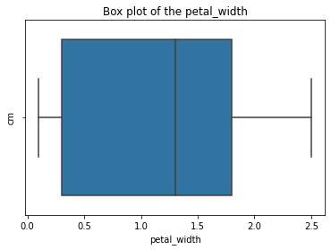

```python
# Create the boxplot of the "total bill" amounts
sns.boxplot(ds["petal_width"], orient = "h").set_title("Box plot of the petal_width")
plt.xlabel("petal_width")
plt.ylabel("cm")
plt.show
```

```
<function matplotlib.pyplot.show(close=None, block=None)>
```

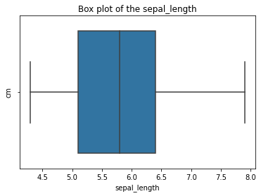

```python
# Create the boxplot of the "tips" amounts
sns.boxplot(ds["sepal_length"]).set_title("Box plot of the sepal_length")
plt.xlabel("sepal_length")
plt.ylabel("cm")
plt.show
```

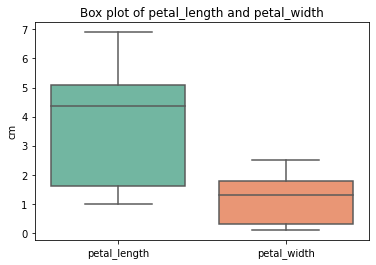

```python
# Create the boxplots of the "Wingspan" and of the "Height" amounts
x = ds.loc[:,["petal_length", "petal_width"]]
x2bp = sns.boxplot(data = x, orient = "v", palette = "Set2")
x2bp.set_title("Box plot of petal_length and petal_width")
plt.ylabel("cm")
plt.show()
```

[figure not shown]

```python
# Create the boxplots of the "Wingspan" and of the "tips" amounts
x = ds.loc[:,["sepal_length", "sepal_width"]]
x2bp = sns.boxplot(data = x, orient = "v", palette = "Set2")
x2bp.set_title("Box plot of petal_length and petal_width")
plt.ylabel("cm")
plt.show()
```

### Boxplots plotted by groups

While looking at a single variable is interesting, it is often useful to see how a variable changes in response to another. Thus, we can create a side-by-side boxplots of one quantitative variable grouped by another categorical variables.

```python
# Create side-by-side boxplots of the "Height" grouped by "Gender"
sns.boxplot(x = ds["petal_length"], y = ds["Class"])
plt.show()
```

[output not shown]

### Histograms and boxplots plotted by groups

We cal also create both boxplots and histograms of one quantitative variable grouped by another categorical variables

```python
# Create a boxplot and histogram of the "tips" grouped by "Gender"
sns.boxplot(data = ds, x = "petal_length", y = ds["Class"])
sns.displot(ds["sepal_length"], kde = False)
plt.show()
```

[output not shown]

```python
# scatter plot between two variables
sns.boxplot(x = ds["petal_length"], y = ds["Class"])
plt.show()
```

[output not shown]

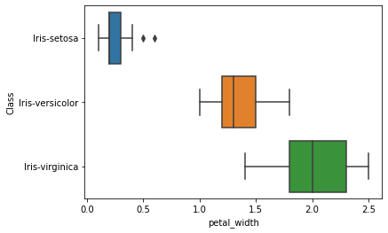

```python
# scatter plot between two variables (one categorical)
sns.boxplot(x = ds["petal_width"], y = ds["Class"])
plt.show()
```

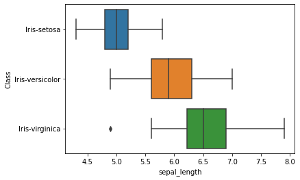

```python
# scatter plot between two variables (one categorical)
sns.boxplot(x = ds["sepal_length"], y = ds["Class"])
plt.show()
```

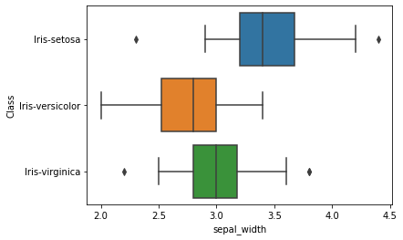

```python
# scatter plot between two variables grouped according to a categorical variable
sns.boxplot(x = ds["sepal_width"], y = ds["Class"])
plt.show()
```

```python
# scatter plot between two variables grouped according to a categorical variable and with size of markers
```

# Activity3: work with the iris dataset

Repeat this tutorial with the iris data set and respond to the following inquiries

```
Provide a description (explaination from your observations) of each of the quantitative variables

We can conclude that the sepal is mostly bigger in length and width than the petal
```

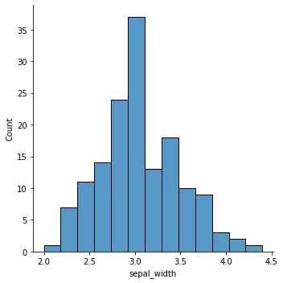

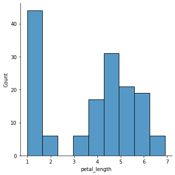

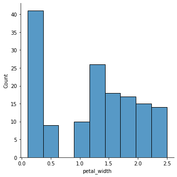

```python
#Plot the histograms for each of the four quantitative variables
sns.displot(ds["sepal_length"], kde = False)
sns.displot(ds["sepal_width"], kde = False)
sns.displot(ds["petal_length"], kde = False)
sns.displot(ds["petal_width"], kde = False)
plt.show()
```

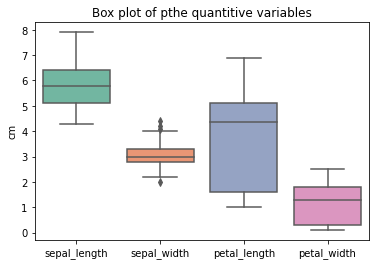

```python
#Plot the boxplots for each of the quantitative variables
x = ds.loc[:,["sepal_length", "sepal_width", "petal_length", "petal_width"]]
x2bp = sns.boxplot(data = x, orient = "v", palette = "Set2")
x2bp.set_title("Box plot of pthe quantitive variables")
plt.ylabel("cm")
plt.show()
```

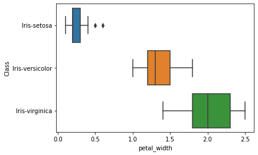

```python
#Plot the boxplots of the petal width grouped by type of flower
sns.boxplot(x = ds["petal_width"], y = ds["Class"])
plt.show()
```

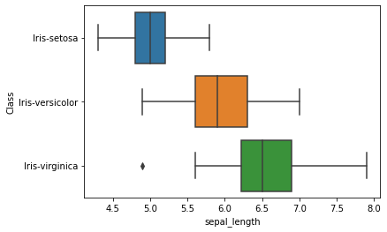

```python
#Plot the boxplots of the sepal length grouped by type of flower
sns.boxplot(x = ds["sepal_length"], y = ds["Class"])
plt.show()
```